# GridMap

# Use GridMap to create levels in a 3D grid out of cells

`GridMap` lets you create levels quickly in the editor using preset cells, similar to `TileMap` but in 3D.

In this guide, you’ll learn to:

- Set up a `GridMap` node and use its key methods.
- Create a level where players can build and destroy several different building types.
- Make levels that contain probabilistic cells, which are randomly replaced with a chosen cell type once the game runs.
- Code an autotiling feature to your `GridMap` that connects adjacent cells to have a continuous racetrack.

Contents:

- Setting up a GridMap node
  - Creating a MeshLibrary from a Scene
  - Editing the GridMap using the built-in editor
- Using a GridMap in practice
  - Creating and erasing buildings on a map
  - Generating levels using probabilistic cells
  - A racetrack editor with autotiling
- Troubleshooting
  - GridMap updates a cell next to the one I want to change

## Setting up a GridMap node

`GridMap` is Godot’s 3D equivalent of a `TileMap` node. Similar to tile maps, grid maps require some setup before using them.

Unfortunately, some of the `TileMap` node’s nicer features don’t exist in its 3D counterpart, like the tileset editor.

However, you can still use a `GridMap` node to quickly create levels out of cells in the editor or using procedural generation.

### Creating a MeshLibrary from a Scene

You populate cells in a `GridMap` with meshes from a `MeshLibrary` resource. You create a mesh library from a collection of 3D models in a scene, ideally each with the same dimensions.

First, create a scene containing all the meshes you want to use in the `GridMap` as `MeshInstance` nodes. Add any `CollisionShape` children to the meshes that need to collide with things.

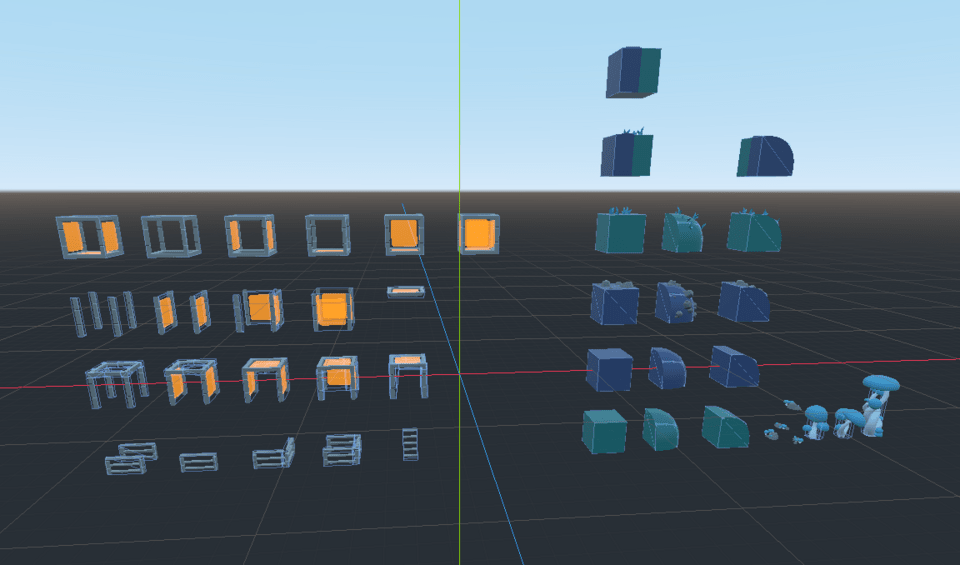

You can create such a scene in Blender and export it using the GLTF file format. That’s what we did for the above mesh library.

Once you are happy with the meshes, you can convert the scene to a `MeshLibrary` by going to *Scene -> Convert To… -> MeshLibrary…*.

You can save the resource file as `.tres` to keep it text-based or as `.meshlib` if you prefer a binary format.

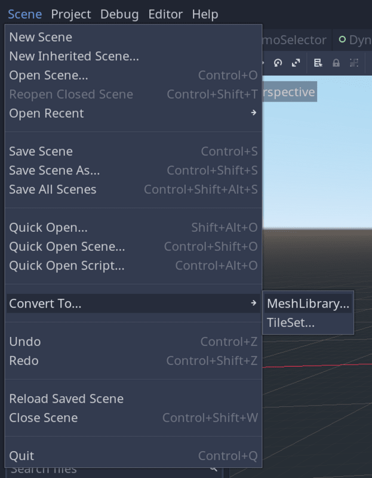

To use your mesh library, create a `GridMap` node and drag and drop the file onto the *Mesh Library* property in the *Inspector*.

The available tiles appear on the right of the viewport.

Each tile has a name and a unique index. You use the index to get or set a cell in the `GridMap`. The value starts at `0` and increases by one for each subsequent mesh.

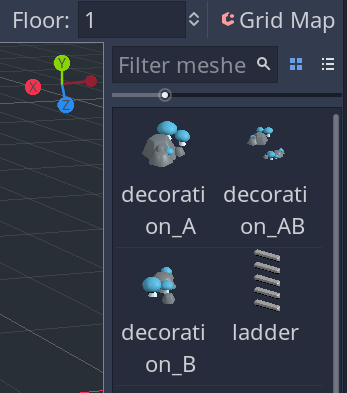

### Editing the GridMap using the built-in editor

Select a tile from the list of meshes and left-click and drag in the viewport to draw cells. To erase cells, right-click instead.

You can rotate the selected tile around the X, Y, and Z axes using the `A`, `S`, and `D` keys, respectively.

The `Q` and `E` keys move the floor level up and down to let you place cells higher and lower in the world. Alternatively, you can use the mouse wheel.

You can use the `Z`, `X`, and `C` keys to turn the grid and align it with the world’s X, Y, and Z axes, respectively. When changing the editing axis, the `Q` and `E` keys move forward and backward alongside it.

Finally, you can use `Shift` + left-click to drag a selection on the `GridMap` and delete, cut, copy and paste the selection.

**Note:** It takes time to get used to those shortcuts.

## Using a GridMap in practice

Let’s see some powerful ways you can use the node in your games.

### Creating and erasing buildings on a map

Many games let you build and demolish buildings.

It is a common feature in city-building and strategy games such as *Stronghold*. It’s also a staple in the *Sims* series, where you build houses and place furniture in them.

[figure not shown]

*Game: Stronghold HD*

Often, you can only place buildings on a grid. Defining precise areas to interact with makes the player’s experience easier.

Using a grid-based approach also simplifies your job by making it easier for AIs to interact with your world.

In this demo, the player can place and erase buildings from a map, following two rules:

1. You can only place buildings on a flat floor.
2. You can’t stack buildings on top of each other.

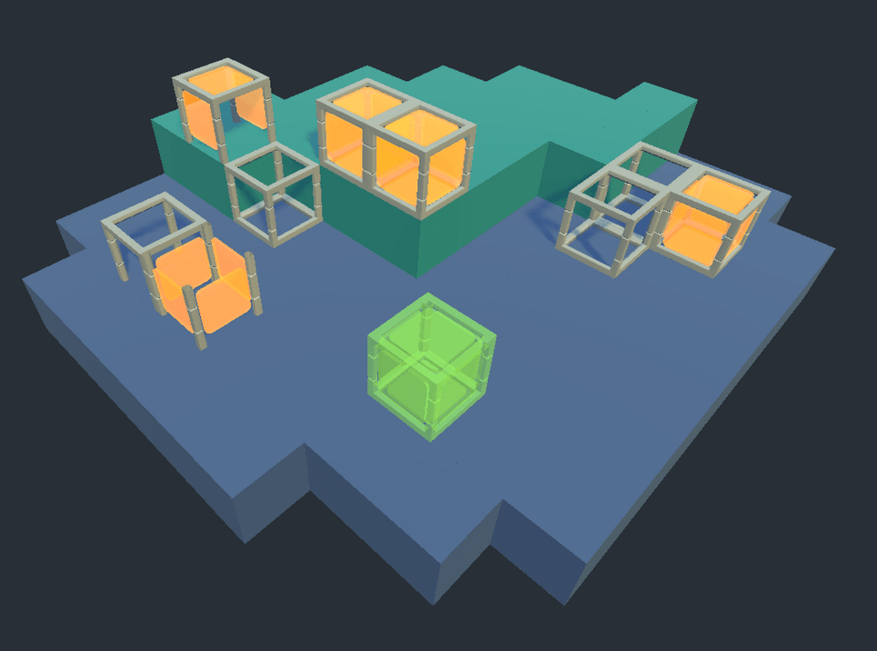

We have a `MeshInstance` named *Preview* to give the player visual feedback on where the next building will go and what it will look like.

Feedback like a preview mesh is a great way to enhance the user experience. Showing a ghost of the building the player is about to place goes a long way in making your game easy to play.

A `GridMap` node handles many of the demo’s features, such as the grid itself and telling us what each cell contains. The `GridMap` also lets us assign tiles to grid cells in code.

To start, we need to define the meshes we want to let the player build and which tiles are valid floors.

**Note:** You can find the indices of each tile by selecting the `MeshLibrary` resource and viewing them in the *Inspector*.

```
# We load our mesh library to display a preview of the mesh the player's about
# to build.
const MESH_LIBRARY: MeshLibrary = preload("res://common/Environment/space_environment_meshlib.tres")
## We set the mesh preview to this green color if the player can build on the
## hovered cell.
const VALID_CELL_COLOR := Color(0.560784, 0.870588, 0.364706, 0.6)
## We set the mesh preview to this red color if the player can't build on the
## hovered cell.
const INVALID_CELL_COLOR := Color(0.921569, 0.337255, 0.294118, 0.6)

# Below are tile indices corresponding to empty cells, buildings the player can
# cycle through, and tiles over which the player can build.
const EMPTY_CELL_INDEX := -1
const BUILDING_OPTIONS := [22, 27, 29, 30, 33]
const FLOOR_CELL_IDS := [9, 12]

onready var _gridmap: GridMap = $GridMap
onready var _preview: MeshInstance = $Preview
# We need the camera to detect where the player clicks.
onready var _camera: Camera = $Camera

## The grid coordinates of the hovered cell.
var _cell := Vector3.INF
## The index of the building to place on the map.
var _building_index := 1 setget _set_building_index
```

In `_unhandled_input()`, we call our main functions.

```
func _unhandled_input(event: InputEvent) -> void:
    # Every time the player moves the mouse, we want to update the preview if
    # necessary.
    if event is InputEventMouseMotion:
        _update_preview()
    elif event.is_action_pressed("click") and can_build_in_hovered_cell():
        build()
    elif event.is_action_pressed("right_click"):
        erase_building()
    # The player can cycle through the list of tiles in `BUILDING_OPTIONS by
    # pressing A and D.
    elif event.is_action_pressed("ui_left"):
        _set_building_index(_building_index - 1)
    elif event.is_action_pressed("ui_right"):
        _set_building_index(_building_index + 1)
```

To determine what the mouse is hovering over, we cast a ray from the camera and see what it finds.

For that, we define a new function, `_cast_ray_from_mouse()`.

It casts a ray from the camera and returns a dictionary with details about what the ray hit.

If the ray doesn’t hit anything, the function returns an empty dictionary.

While we could use a `RayCast` node, we use Godot’s physics server directly to make our physics query. This approach can give you a lot of flexibility and offers better performance compared to using nodes.

This example casts a ray one thousand units out into the world directly perpendicular to the camera.

```
func _cast_ray_from_mouse() -> Dictionary:
    var mouse_position := get_viewport().get_mouse_position()
    # This method projects screen coordinates to where the camera node is in the
    # 3D world.
    var from: Vector3 = _camera.project_ray_origin(mouse_position)
    # And this one projects the position from the camera into the world.
    # You want to multiply the result for the ray to be long enough to ensure
    # it'll hit the ground.
    var to: Vector3 = from + _camera.project_ray_normal(mouse_position) * 1000
    # This PhysicsDirectSpaceState object gives us a door into the world's
    # physics.
    var space_state := get_world().direct_space_state
    # With it, we can do raycast checks and much more.
    return space_state.intersect_ray(from, to, [self])
```

Next, we update our preview. We first need to cast a ray with `_cast_ray_from_mouse()`.

If the function returns an empty dictionary, the mouse isn’t over a cell, and we hide the preview.

Otherwise, we update the preview mesh’s position and color.

```
func _update_preview() -> void:
    var result := _cast_ray_from_mouse()
    if result.empty():
        _preview.hide()
    else:
        # This converts the position the ray hit into grid coordinates.
        _cell = _gridmap.world_to_map(result.position)

        # We turn the preview green if the player can build. Otherwise, we make
        # it red.
        var color: Color = VALID_CELL_COLOR if can_build_in_hovered_cell() else INVALID_CELL_COLOR
        _preview.material_override.albedo_color = color

        # We convert the grid coordinates back to world coordinates to snap the
        # preview to the center of the cell.
        _preview.global_transform.origin = _gridmap.map_to_world(_cell.x, _cell.y, _cell.z)
        _preview.show()
```

Here are three helper functions we use to check the cell where the player wants to build or erase a building. We already used `can_build_in_hovered_cell()` above.

In that function, we check two rules:

1. The hovered cell is empty.
2. The cell below the hovered one is either a green or blue floor cell.

```
func can_build_in_hovered_cell() -> bool:
    return is_hovered_cell_empty() and is_cell_floor(Vector3(_cell.x, _cell.y - 1, _cell.z))


func is_hovered_cell_empty() -> bool:
    # GridMap.get_cell_item() returns the index of the tile at the specified
    # coordinates.
    return _gridmap.get_cell_item(_cell.x, _cell.y, _cell.z) == EMPTY_CELL_INDEX


func is_cell_floor(cell: Vector3) -> bool:
    return _gridmap.get_cell_item(cell.x, cell.y, cell.z) in FLOOR_CELL_IDS
```

We only call the build function if the player hovers over a valid cell, so all it does is update the corresponding `GridMap` cell.

```
func build() -> void:
    _gridmap.set_cell_item(_cell.x, _cell.y, _cell.z, BUILDING_OPTIONS[_building_index])
```

The `GridMap.set_cell_item()` method assigns a tile to a given cell by passing in X, Y, and Z coordinates and a tile’s index. There’s an optional `orientation` argument to rotate the tile.

You can also erase the content of a cell by passing in a `-1` as the tile’s index, as we do in the `erase()` method.

```
# Called in _unhandled_input() when the player right clicks
func erase_building() -> void:
    if not is_cell_floor(Vector3(_cell.x, _cell.y - 1, _cell.z)):
        _gridmap.set_cell_item(_cell.x, _cell.y - 1, _cell.z, EMPTY_CELL_INDEX)
    elif not is_cell_floor(Vector3(_cell.x, _cell.y, _cell.z)):
        _gridmap.set_cell_item(_cell.x, _cell.y, _cell.z, EMPTY_CELL_INDEX)
```

Each mesh used by the `GridMap` has a `CollisionShape`, which may be a box the size of the cell or a more detailed small shape.

If the `CollisionShape` is the size of a cell in the `GridMap`, we get a collision position that is not in the cell we want but in the closest neighbor.

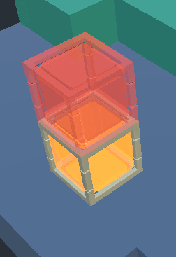

If you place a cube building and mouse over the top face, the preview appears on top of the cube.

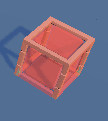

Alternatively, the `CollisionShape` may be more detailed like on the table-shaped mesh, which lets us hover over the cell the mesh is in.

An alternative would be to use two `GridMap` nodes: one for the floor you can build on and one for the buildings. That way, you can cast rays that only intersect with the floor.

You then need to check for existing buildings at those positions on the second `GridMap` node.

### Generating levels using probabilistic cells

A `GridMap` is not just useful to create levels by hand. You can also use them to generate levels out of predefined meshes.

One approach that does not involve generating the entire level from scratch is using probabilistic cells in handcrafted rooms.

*Spelunky* is a popular game that uses this technique.

[figure not shown]

In *Spelunky*, each level is a four-by-four grid filled with hand-designed rooms. In this game, the level designer manually draws probabilistic cells in each room that an algorithm randomizes at the start of the level. These cells can be hazards, enemies, or floor tiles that may or may not appear.

A major benefit of this procedural generation algorithm is you have a lot of control over how levels look and play. The algorithm’s also not too complex.

This example shows you how to use a `GridMap` to create a level and fill it with probabilistic cells. When the level loads, it replaces all the probabilistic cells with either an empty cell or a tree. We also add some additional decorations in the form of some grass and rocks to make the scene look more attractive.

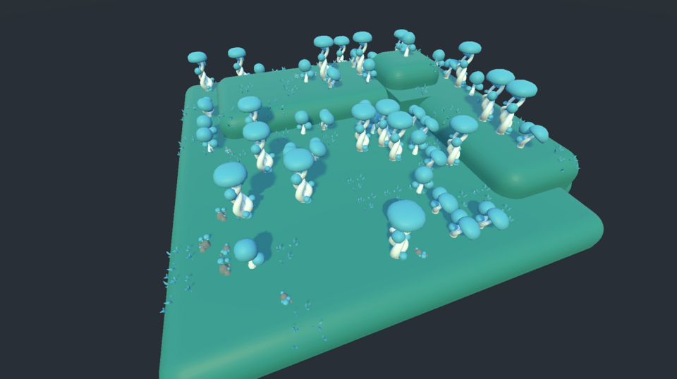

First, we select a specific tile index corresponding to our probabilistic cells. That way, we can draw it by hand and replace it at runtime. We also store the indices of the tiles we want to fill those cells with at runtime.

```
# Those constants store the indices of the cells we work with.
const SOLID_CELLS := [11, 12, 13]
const FLAT_SOLID_CELL := 12
const DECORATED_SOLID_CELLS := [7, 6, 17]
const TREE_CELLS := [3, 4, 5]
const DECORATION_CELLS := [0, 1, 2]
const PROBABILISTIC_CELL := 9
const EMPTY_CELL := -1

# Probability to replace a grey cell with a tree.
export(float, 0.0, 1.0) var probabilistic_cell_chance := 0.45
# Probability to place a decoration over floor cells.
export(float, 0.0, 1.0) var decoration_chance := 0.2

onready var _gridmap: GridMap = $GridMap

onready var _probabilistic_cells := find_probabilistic_cells()
```

Our probabilistic cell is a grey tile, so we can quickly identify it in the editor.

We draw it where we want trees to appear in the level.

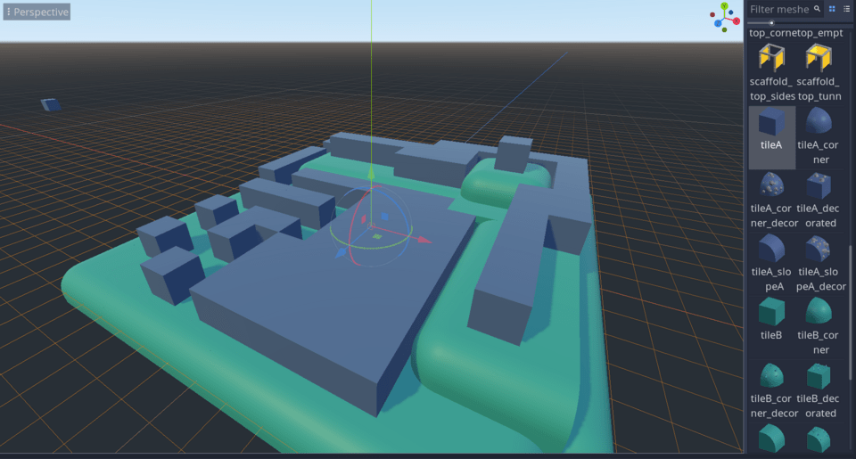

While the `TileMap` node comes with a function to find all tiles with a specific index, the `GridMap` node, unfortunately, does not provide a similar method, so we have to write it ourselves:

```
func find_probabilistic_cells() -> Array:
    var cells := []
    for cell in _gridmap.get_used_cells():
        if is_cell_of_type(cell, PROBABILISTIC_CELL):
            cells.append(cell)
    return cells
```

We split our level generation into three functions for readability:

```
func generate_random_map() -> void:
    _randomize_probabilistic_cells()
    _add_random_cell_decorations()
    _add_random_additional_decorations()
```

Those functions use the following three helper functions, which we use to make the code a bit easier to read.

```
## Replaces one cell with a random one from the `possible_tiles` array.
func randomize_cell(cell: Vector3, possible_tiles: Array) -> void:
    var tile: int = possible_tiles[randi() % possible_tiles.size()]
    _gridmap.set_cell_item(cell.x, cell.y, cell.z, tile)


func is_cell_of_type(cell: Vector3, type: int) -> bool:
    return _gridmap.get_cell_item(cell.x, cell.y, cell.z) == type


func is_cell_in_group(cell: Vector3, group: Array) -> bool:
    return _gridmap.get_cell_item(cell.x, cell.y, cell.z) in group
```

Each new level takes the base terrain drawn in the `GridMap` and:

1. Replaces some probabilistic cells with trees.
2. Replaces some green floor cells with grassy variants.
3. Adds rock decorations above some of the remaining flat green cells.

First, we check each probabilistic cell location and randomly replace some with one of three tree meshes. We erase the remaining grey cells.

```
func _randomize_probabilistic_cells() -> void:
    for cell in _probabilistic_cells:
        if randf() < probabilistic_cell_chance:
            randomize_cell(cell, TREE_CELLS)
        else:
            _gridmap.set_cell_item(cell.x, cell.y, cell.z, EMPTY_CELL)
```

The following function replaces some green floor cells with a grass-covered variation.

We have to copy the orientation of replaced cells so the replacement faces the correct way.

```
func _add_random_cell_decorations() -> void:
    for cell in _gridmap.get_used_cells():
        if not is_cell_in_group(cell, SOLID_CELLS) or randf() > decoration_chance:
            continue

        # As we can rotate tiles in the editor, we need to copy the existing
        # cell's orientation.
        var cell_orientation := _gridmap.get_cell_item_orientation(cell.x, cell.y, cell.z)
        var cell_type := _gridmap.get_cell_item(cell.x, cell.y, cell.z)
        # We arranged our constant arrays so the tile indices in `SOLID_CELLS`
        # match the decorated variant in `DECORATED_SOLID_CELLS`.
        var decorated_replacement: int = DECORATED_SOLID_CELLS[SOLID_CELLS.find(cell_type)]
        _gridmap.set_cell_item(
            cell.x, cell.y, cell.z, decorated_replacement, cell_orientation
        )
```

The final step involves adding some rocks to the remaining free floor cells.

The rocks can only end up on a flat surface so we only place them in an empty cell above a square green cell.

```
func _add_random_additional_decorations() -> void:
    for cell in _gridmap.get_used_cells():
        var cell_above: Vector3 = cell + Vector3.UP
        var can_decorate := (
            is_cell_of_type(cell, FLAT_SOLID_CELL)
            and is_cell_of_type(cell_above, EMPTY_CELL)
        )
        if not can_decorate or randf() > decoration_chance:
            continue

        randomize_cell(cell_above, DECORATION_CELLS)
```

We generate levels in `_unhandled_input()`, when the player presses `Space` or `Enter`.

```
func _unhandled_input(event: InputEvent) -> void:
    if event.is_action_pressed("ui_accept"):
        reset_map()
        generate_random_map()
```

Before doing so, we reset the map first. In the `reset()` function, we restore probabilistic tiles and remove decorations.

A simpler alternative would be to store the map as a scene and instantiate a fresh copy. That’s what you’d want to do in a complete level generator.

To learn how to generate complete levels, check out [Godot PCG Secrets](https://gdquest.mavenseed.com/courses/godot-pcg-secrets). Although the content focuses on 2D, the grid-based generation algorithms work similarly in 3D with `GridMap`.

### A racetrack editor with autotiling

Unlike the 2D `TileMap`, the `GridMap` node doesn’t come with built-in autotiling. Autotiling is a feature that changes tiles as you draw to create paths and more.

In this demo, we build a track editor where tiles update automatically as you draw. The meshes we use here come from Godot’s [GridMap demo](https://docs.godotengine.org/en/stable/tutorials/3d/using_gridmaps.html).

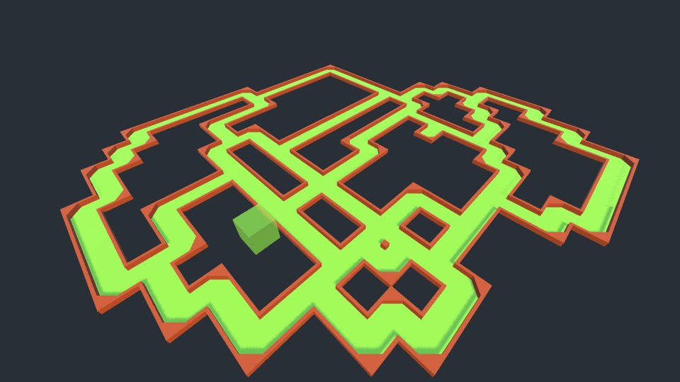

We want the player to draw tracks by clicking and dragging on a grid. They don’t have to worry about selecting different tiles. Also, right-clicking should erase the track.

This example takes place on a flat plane. While the principles we present here apply to maps with different elevations, it’s easier to wrap your head around 2D autotiling first.

Working with a single plane at a time simplifies mouse calculations too.

Let’s start with input and how we update the current cell every frame.

We poll for input in `_physics_process()` as it makes it easy to detect when the player drags the mouse.

Also, every time the mouse moves, we update the preview and draw or erase some road cells. This happens in `update_current_cell()`, which you can see below.

As we only need to check for a flat plane, we use the `Plane.intersects_ray()` method to find which `GridMap` cell the player is hovering.

```
# List all the modes we support in our racetrack editor.
enum DrawingState { DRAWING, ERASING, IDLE }

const OFFSET := 0.001

var _drawing_state: int = DrawingState.IDLE
## Coordinates of the cell the player is currently hovering.
var _current_cell := Vector3.INF

onready var _gridmap: GridMap = $GridMap
onready var _camera: Camera = $Camera
onready var _preview: MeshInstance = $Preview

func update_current_cell(mouse_position: Vector2) -> void:
    # To ensure every cell is on the same Y level, the raycast is set to
    # intersect with a flat plane at Y = 0.
    #
    # We use the `OFFSET` constant to move the plane up a tiny amount to avoid
    # issues with world_to_map() if the intersection is on the border between
    # two cells.
    var intersection := Plane(Vector3.UP, OFFSET).intersects_ray(
        _camera.project_ray_origin(mouse_position), _camera.project_ray_normal(mouse_position)
    )
    _current_cell = _gridmap.world_to_map(intersection)
    _preview.global_transform.origin = _gridmap.map_to_world(
        _current_cell.x, _current_cell.y, _current_cell.z
    )

    if _drawing_state == DrawingState.DRAWING:
        place_road()
    elif _drawing_state == DrawingState.ERASING:
        erase_road()
```

#### The autotiling algorithm

When the player draws or erases a tile, we automatically update surrounding tiles to create corners and intersections.

Our race track consists of meshes of corners and junctions, which can have one of four different rotations. Each cell can also be different based on which of the four neighboring cells are also part of the track.

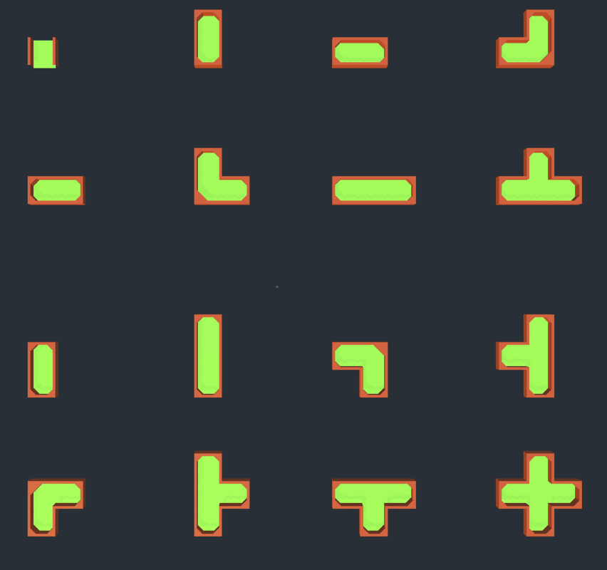

We can represent all sixteen arrangements in a 4-bit binary value from `0000` to `1111` (equivalent to `0` to `15` in base ten).

From right to left, the bits correspond to a cell’s forward, left, right, and back neighbors. When drawing one tile, if there is a road tile in a neighboring cell, we set the corresponding bit with a `1`. Otherwise, we set it to `0`.

We can then map each unique configuration to a tile to draw in the current cell. For simplicity, in this example, we always update all tiles when drawing. This works fine for cases where you generate autotiles once upon generating a map or starting the game.

```
# Every time we update a cell, we need to loop over its neighbors and update
# them too. This array stores the relative position of all neighbors of a cell.
const NEIGHBORS := [Vector3.FORWARD, Vector3.LEFT, Vector3.RIGHT, Vector3.BACK]

func update_all_autotiles() -> void:
    for cell in _gridmap.get_used_cells():
        # This variable is a number representing the configuration of neighbors.
        var autotile_index := 0
        # For each neighbor cell with a road, we add the corresponding power of
        # two to `autotile_index`.
        for neighbor in NEIGHBORS:
            if is_cell_empty(cell + neighbor):
                continue
            # We use the bit shifting operator `<<` here.
            #
            # Bit shifting by the index of the neighbor is equivalent to
            # calling `pow(2, index)`.
            #
            # Bitwise operations are generally much more efficient than
            # calling the pow() function.
            autotile_index += 1 << NEIGHBORS.find(neighbor)
        autotile_cell(cell, autotile_index)


func autotile_cell(cell: Vector3, autotile_index: int) -> void:
    for map in AUTOTILE_INDEX_MAP:
        if autotile_index in map.rotation_map.keys():
            _gridmap.set_cell_item(
                cell.x, cell.y, cell.z, map.cell_type, map.rotation_map[autotile_index]
            )
            return
    _gridmap.set_cell_item(cell.x, cell.y, cell.z, STRAIGHT_ROAD)
```

Since we can calculate a value to represent which neighbors of any given track cell are more track, we map all the possible values to the corresponding mesh to connect all neighbors.

```
# This constant holds values for specific GridMap cell orientations. This allows
# us to rotate and reuse our road tiles as much as possible.
const ORTHOGONAL_MAP := {"North": 16, "East": 0, "South": 22, "West": 10}
# This array of dictionary maps calculated autotile indices to the cell ID and rotation.
const AUTOTILE_INDEX_MAP := [
    {
        "cell_type": CORNER_ROAD,
        "rotation_map":
        {
            3: ORTHOGONAL_MAP.West,
            5: ORTHOGONAL_MAP.North,
            10: ORTHOGONAL_MAP.South,
            12: ORTHOGONAL_MAP.East
        }
    },
    {
        "cell_type": STRAIGHT_ROAD,
        "rotation_map": {6: ORTHOGONAL_MAP.South, 9: ORTHOGONAL_MAP.West}
    },
    {
        "cell_type": T_ROAD,
        "rotation_map":
        {
            7: ORTHOGONAL_MAP.West,
            13: ORTHOGONAL_MAP.North,
            14: ORTHOGONAL_MAP.East,
            11: ORTHOGONAL_MAP.South
        }
    },
    {
        "cell_type": FOUR_WAY_ROAD,
        "rotation_map": {15: ORTHOGONAL_MAP.North}
    },
    {
        "cell_type": CAP_ROAD,
        "rotation_map":
        {
            1: ORTHOGONAL_MAP.West,
            2: ORTHOGONAL_MAP.South,
            4: ORTHOGONAL_MAP.North,
            8: ORTHOGONAL_MAP.East
        }
    },
]
```

Each possible value except for zero is present in one of the `rotation_map` keys.

The developers of Godot have helpfully created a map of the twenty-four possible `Basis` values that represent the rotations we can have for a cell in our `GridMap`. For our race track editor, we only need four indices corresponding to rotations around the Y-axis.

You can get those unique indices from a `Basis` object by calling `Basis.get_orthogonal_index()`.

## Troubleshooting

### GridMap updates a cell next to the one I want to change

If you use the `GridMap.world_to_map()` method to convert a world position into a cell’s coordinates, the node will snap to the cell the point is in.

If the position is on the border of a cell, for example when you shoot a ray from the `Camera` at a cube-shaped cell, `GridMap` may snap the position to the adjacent cell.

This issue can happen when casting rays onto the map.

If your tiles’ colliders are perfect cubes, the ray hits a face and returns a position right between grid cells.

You can offset the position using the collision normal to get the cell you want.

For example, if you use `PhysicsDirectSpaceState.intersect_ray()` to detect where the player clicked, the function will return a dictionary with a `normal` key.

```
# We calculate the ray's `start_position` and `end_position`...
# Then, we cast it.
var space_state := get_world().direct_space_state
var result: Dictionary = space_state.intersect_ray(start_position, end_position, _gridmap_node)
var offset_position := result.position - result.normal * 0.1
```

The new `offset_position` is slightly inside the cell the ray collided with and guarantees `GridMap.world_to_map()` returns the cell you want.